# set4

# Problem Set 4

## **Problem 1 - Tidyverse: New Zealand**

Install and load the package [**nzelect**](https://cran.r-project.org/package=nzelect). This package contains a number of data tables with information about election results in New Zealand. Use the `nzge` data for this problem.

Note that there are two types of votes cast - a Candidate vote, and a Party vote. Be sure to handle these separately as appropriate.

a. Generate a table (which can just be a nicely printed tibble) of vote count (regardless of party) per year/type. Make sure to sort it by vote count.

```r
library(nzelect)
library(dplyr)
data("nzge")
head(nzge)
```

```
  approx_location                 voting_place           party votes electorate
1          Albury                       School ACT New Zealand    16     Aoraki
2       Arowhenua Maori School, Huirapa Street ACT New Zealand     4     Aoraki
3      Burke Pass                  Alpine Café ACT New Zealand    13     Aoraki
4      Cannington                       School ACT New Zealand     6     Aoraki
5    Cattle Creek                       School ACT New Zealand     1     Aoraki
6            Cave                         Hall ACT New Zealand    16     Aoraki
  voting_type candidate election_year electorate_number
1       Party      <NA>          2002                 1
2       Party      <NA>          2002                 1
3       Party      <NA>          2002                 1
4       Party      <NA>          2002                 1
5       Party      <NA>          2002                 1
6       Party      <NA>          2002                 1
```

```r
nzge_a <- nzge %>% group_by(election_year,voting_type) %>% summarise(total_votes = sum(votes, na.rm = TRUE)) %>% arrange(desc(total_votes))
nzge_a
```

```
# A tibble: 10 × 3
# Groups:   election_year [5]
   election_year voting_type total_votes
           <dbl> <chr>             <dbl>
 1          2014 Party           2416479
 2          2014 Candidate       2375493
 3          2008 Party           2356536
 4          2008 Candidate       2325598
 5          2005 Party           2286190
 6          2005 Candidate       2260670
 7          2011 Party           2257336
 8          2011 Candidate       2225766
 9          2002 Party           2040248
10          2002 Candidate       2022115
```

b. Focus only on the 2014 election. Report the proportion of votes for each party in the Candidate election. Again, produce a nice table and sort it by percent of vote.

```r
nzge_b <- nzge %>% filter(election_year==2014, voting_type=='Candidate') %>% group_by(party) %>% summarise(total_votes = sum(votes, na.rm = TRUE),.groups = "drop") %>% mutate(percent = round(100*total_votes / sum(total_votes),1)) %>% arrange(desc(percent))

nzge_b
```

```
# A tibble: 25 × 3
   party                    total_votes percent
   <chr>                          <dbl>   <dbl>
 1 National Party               1081787    45.5
 2 Labour Party                  801287    33.7
 3 Green Party                   165718     7
 4 Conservative Party             81075     3.4
 5 New Zealand First Party        73384     3.1
 6 Maori Party                    42108     1.8
 7 MANA Movement                  32333     1.4
 8 ACT New Zealand                27778     1.2
 9 Informal Candidate Votes       27886     1.2
10 United Future                  14722     0.6
# ℹ 15 more rows
```

c. Produce a nice table indicating, for each year, which party won the Candidate vote and which party won the Party vote.

```r
library(tidyr)

nzge_c <- nzge %>%
  group_by(election_year, voting_type, party) %>%
  summarise(total_votes = sum(votes, na.rm = TRUE), .groups = "drop") %>%
  group_by(election_year, voting_type) %>%
  slice_max(total_votes, with_ties = FALSE) %>%
  ungroup() %>%
  pivot_wider(
    names_from = voting_type,
    values_from = party,
    names_glue = "{voting_type}_winner"
  ) %>%
  arrange(election_year)

nzge_c
```

```
# A tibble: 10 × 4
   election_year total_votes Candidate_winner Party_winner
           <dbl>       <dbl> <chr>            <chr>
 1          2002      891866 Labour Party     <NA>
 2          2002      838219 <NA>             Labour Party
 3          2005      902874 National Party   <NA>
 4          2005      935319 <NA>             Labour Party
 5          2008     1072024 National Party   <NA>
 6          2008     1053398 <NA>             National Party
 7          2011     1027696 National Party   <NA>
 8          2011     1058636 <NA>             National Party
 9          2014     1081787 National Party   <NA>
10          2014     1131501 <NA>             National Party
```

## **Problem 2 - Tidyverse: Tennis**

Use the “ATP Matches” data from 2019 available at https://raw.githubusercontent.com/JeffSackmann/tennis_atp/refs/heads/master/atp_matches_2019.csv. This data tracks all Tennis matches. This data does *not* have documentation, so you’ll have to explore the data yourself to figure out it’s structure. Use it to answer the following questions. Your answers should show both the output from R that allows you to answer it, as well as a written answer.

```r
tennis=read.csv('./atp_matches_2019.csv')
head(tennis)
```

```
  tourney_id tourney_name surface draw_size tourney_level tourney_date
1  2019-M020     Brisbane    Hard        32             A     20181231
2  2019-M020     Brisbane    Hard        32             A     20181231
3  2019-M020     Brisbane    Hard        32             A     20181231
4  2019-M020     Brisbane    Hard        32             A     20181231
5  2019-M020     Brisbane    Hard        32             A     20181231
6  2019-M020     Brisbane    Hard        32             A     20181231
  match_num winner_id winner_seed winner_entry        winner_name winner_hand
1       300    105453           2                   Kei Nishikori           R
2       299    106421           4                 Daniil Medvedev           R
3       298    105453           2                   Kei Nishikori           R
4       297    104542          NA           PR Jo-Wilfried Tsonga           R
5       296    106421           4                 Daniil Medvedev           R
6       295    104871          NA                   Jeremy Chardy           R
  winner_ht winner_ioc winner_age loser_id loser_seed loser_entry
```

[output cut: 41 more lines]

```r
# summary(tennis)
```

a. How many tournaments took place in 2019?

```r
tennis_a <- tennis %>%
  filter(tourney_date >= 20190101, tourney_date <= 20191231) %>%
  summarise(num_tournaments = n_distinct(tourney_id))

tennis_a
```

```
  num_tournaments
1             125
```

b. Did any player win more than one tournament? If so, how many players won more than one tournament, and how many tournaments did the most winning player(s) win?

```r
tennis_b <- tennis %>% filter(round=="F") %>% select(tourney_id, winner_name) %>% group_by(winner_name) %>% summarise(t_won = n(), .groups = "drop")

player<- tennis_b %>% filter(t_won > 1)
player
```

```
# A tibble: 12 × 2
   winner_name        t_won
   <chr>              <int>
 1 Alex De Minaur         3
 2 Benoit Paire           2
 3 Cristian Garin         2
 4 Daniil Medvedev        4
 5 Dominic Thiem          5
 6 Jo-Wilfried Tsonga     2
 7 Matteo Berrettini      2
 8 Nick Kyrgios           2
 9 Novak Djokovic         5
10 Rafael Nadal           4
11 Roger Federer          4
12 Stefanos Tsitsipas     3
```

```r
max_wins <- max(tennis_b$t_won)
max_wins
```

```
[1] 5
```

```r
mx_players <- tennis_b %>% filter(t_won == max_wins)
mx_players
```

```
# A tibble: 2 × 2
  winner_name    t_won
  <chr>          <int>
1 Dominic Thiem      5
2 Novak Djokovic     5
```

c. Is there any evidence that winners have more aces than losers? (If you address this with a hypothesis test, do not use base R functionality - continue to remain in the Tidyverse.)

```r
library(infer)
tennis %>% summarise(win_ace= mean(w_ace, na.rm = TRUE),
    lose_ace=mean(l_ace, na.rm = TRUE))
```

```
   win_ace lose_ace
1 7.497402 5.792502
```

```r
tennis_c <- tennis %>% select(w_ace, l_ace) %>%
  mutate(diff = w_ace - l_ace) %>%
  t_test(response = diff, mu = 0)

tennis_c
```

```
# A tibble: 1 × 7
  statistic  t_df  p_value alternative estimate lower_ci upper_ci
      <dbl> <dbl>    <dbl> <chr>          <dbl>    <dbl>    <dbl>
1      12.4  2693 3.06e-34 two.sided       1.70     1.43     1.98
```

It is significant that winners had more aces than losers.

d. Identify the player(s) with the highest win-rate. (Note that this is NOT asking for the highest number of wins.) Restrict to players with at least 5 matches.

```r
wins <- tennis %>% count(winner_name, name = "wins")

plays <- tennis %>% mutate(player = winner_name) %>%
  bind_rows(tennis %>% mutate(player=loser_name)) %>%
  count(player, name = "matches")

win_rate <- wins %>% rename(player = winner_name) %>%
  inner_join(plays, by ="player") %>% filter(matches>= 5) %>%
  mutate(win_rate=wins/matches) %>% arrange(desc(win_rate))

head(win_rate)
```

```
           player wins matches  win_rate
1    Rafael Nadal   60      69 0.8695652
2  Novak Djokovic   58      69 0.8405797
3   Roger Federer   55      66 0.8333333
4 Daniil Medvedev   59      80 0.7375000
5  Kevin Anderson   11      15 0.7333333
6   Dominic Thiem   50      69 0.7246377
```

```r
best_players <- win_rate %>% filter(win_rate == max(win_rate))
head(best_players)
```

```
        player wins matches  win_rate
1 Rafael Nadal   60      69 0.8695652
```

## **Problem 3 - Visualization**

```r
covid=read.csv('./us-states.csv')
head(covid)
```

```
        date  geoid      state cases cases_avg cases_avg_per_100k deaths
1 2020-01-21 USA-53 Washington     1      0.14                  0      0
2 2020-01-22 USA-53 Washington     0      0.14                  0      0
3 2020-01-23 USA-53 Washington     0      0.14                  0      0
4 2020-01-24 USA-53 Washington     0      0.14                  0      0
5 2020-01-24 USA-17   Illinois     1      0.14                  0      0
6 2020-01-25 USA-53 Washington     0      0.14                  0      0
  deaths_avg deaths_avg_per_100k
1          0                   0
2          0                   0
3          0                   0
4          0                   0
5          0                   0
6          0                   0
```

For each of the following, produce a publication-ready plot which addresses the question. Use your plot to support an argument for your question.

a. How many major and minor spikes in cases were there?

```r
library(zoo)
library(ggplot2)

covid <- covid %>% mutate(date = as.Date(date))

covid_a <- covid %>% group_by(date) %>% summarise(cases=sum(cases), .groups = "drop") %>%
  arrange(date)

covid_a <- covid_a %>% mutate(base_mean = rollmean(cases, k = 7, fill = NA, align = "center"),
    base_sd= rollapply(cases, width = 7, sd, fill = NA, align = "center")) %>% mutate(z = (cases - base_mean) / base_sd)

covid_a <- covid_a %>% mutate(class=case_when(z >= 2~"major",z >= 1~"minor",TRUE ~ "none"))

major_spikes <- covid_a %>% filter(class == "major")
minor_spikes <- covid_a %>% filter(class == "minor")

cat("Number of major spikes:", nrow(major_spikes), "\n")
```

```
Number of major spikes: 7
```

```r
cat("Number of minor spikes:", nrow(minor_spikes), "\n")
```

```
Number of minor spikes: 148
```

I standardized COVID case counts using a 7-day rolling mean and standard deviation to calculate a local z-score for each date. A major spike was defined as a day when cases exceeded the 7-day baseline by at least **two standard deviations** (z ≥ 2), while a minor spike was defined as **one to two standard deviations above baseline** (1 ≤ z < 2). It is shown that there are **7** major spikes and **148** minor spikes.

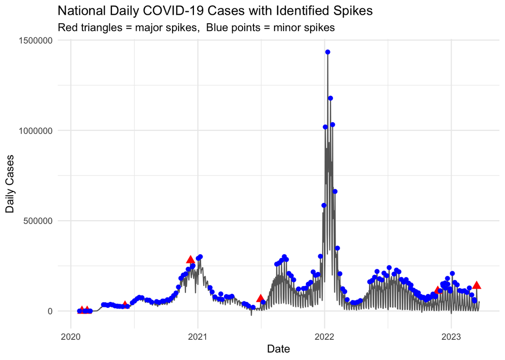

```r
ggplot(covid_a, aes(x = date, y = cases)) + geom_line(color = "gray40", linewidth = 0.5) +
  geom_point(data = major_spikes, aes(x = date, y = cases),
             color = "red", size = 3, shape = 17) +
  geom_point(data = minor_spikes, aes(x = date, y = cases),color = "blue", size = 2, shape = 16) +labs(title = "National Daily COVID-19 Cases with Identified Spikes",
    subtitle = "Red triangles = major spikes,  Blue points = minor spikes",
    x = "Date",y = "Daily Cases") + theme_minimal()
```

b. For the states with the highest and lowest overall rates per population, what differences do you see in their trajectories over time?

```r
covid_b <- covid %>% group_by(state) %>% summarise(mean_rate=mean(cases_avg_per_100k,na.rm=TRUE), .group='drop') %>% arrange(desc(mean_rate))

highest<- covid_b %>% slice(1) %>% pull(state)
lowest<- covid_b %>% slice(n()) %>% pull(state)

highest
```

```
[1] "American Samoa"
```

```r
lowest
```

```
[1] "Maryland"
```

```r
covid_b <- covid %>% filter(state %in% c(highest,lowest))
head(covid_b)
```

```
        date  geoid    state cases cases_avg cases_avg_per_100k deaths
1 2020-03-05 USA-24 Maryland     3      0.43               0.01      0
2 2020-03-06 USA-24 Maryland     0      0.43               0.01      0
3 2020-03-07 USA-24 Maryland     0      0.43               0.01      0
4 2020-03-08 USA-24 Maryland     2      0.71               0.01      0
5 2020-03-09 USA-24 Maryland     1      0.86               0.01      0
6 2020-03-10 USA-24 Maryland     3      1.29               0.02      0
  deaths_avg deaths_avg_per_100k
1          0                   0
2          0                   0
3          0                   0
4          0                   0
5          0                   0
6          0                   0
```

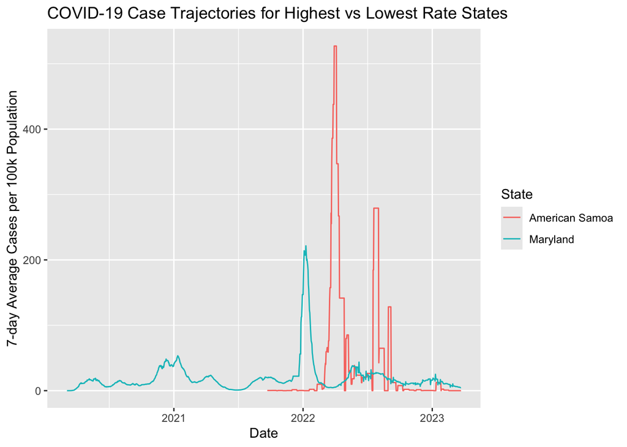

```r
ggplot(covid_b, aes(x = date, y = cases_avg_per_100k, color =state)) + geom_line() +
  labs(title = "COVID-19 Case Trajectories for Highest vs Lowest Rate States", x = "Date", y = "7-day Average Cases per 100k Population", color = "State")
```

c. Identify, to the best of your ability without a formal test, the first five states to experience Covid in a substantial way.

```r
covid_c <- covid %>% filter(cases_avg_per_100k >= 1) %>% group_by(state) %>% summarise(first_surge = min(date), .groups = "drop") %>% arrange(first_surge)

covid_c %>% slice(1:5)
```

```
# A tibble: 5 × 2
  state      first_surge
  <chr>      <date>
1 Washington 2020-03-15
2 New York   2020-03-18
3 Guam       2020-03-19
4 Louisiana  2020-03-19
5 New Jersey 2020-03-19
```

A threshold of 1 case per 100k population average reflects sustained, non-incidental transmission. The first five states and their surge date are listed above.

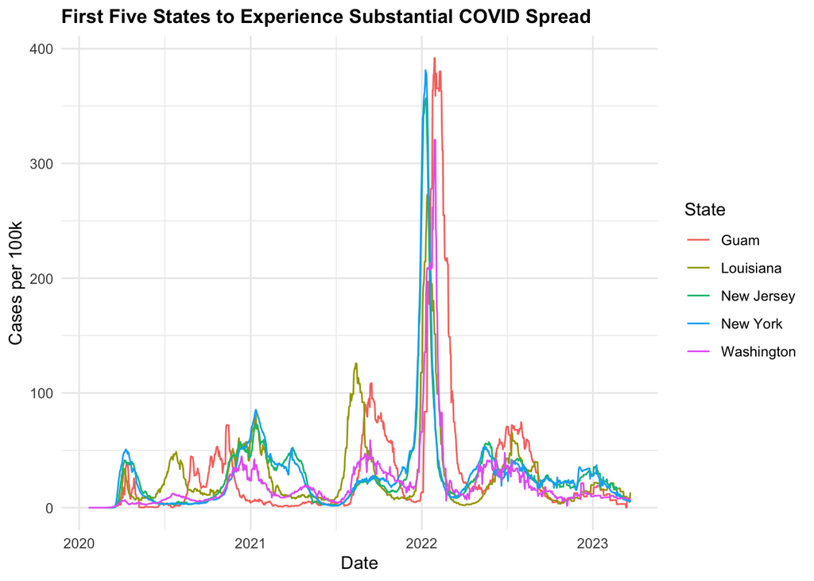

```r
first_five<- covid_c %>% slice(1:5) %>% pull(state)

covid_first5 <- covid %>% filter(state %in% first_five)

ggplot(covid_first5, aes(x = date, y = cases_avg_per_100k, color = state)) +
  geom_line(linewidth = 0.5) +
  labs(title = "First Five States to Experience Substantial COVID Spread",
    x = "Date",
    y = "Cases per 100k",
    color = "State"
  ) +theme_minimal() +theme(plot.title = element_text(size = 12, face = "bold"))
```